# STA308 Homework 4

# Simulating Roulette Streaks over 4 years (1,200 spins/day)

```r
set.seed(314159) # Sets a uniform outcome for each trial
casino_2 <- c() # Creates an empty vector

# Using the same logic as the above trial, instead of 600 spins in a day
# we supposed that the casino speeds up the process to 1,200 spins a day over
# the period of approximately 4 years.

for(i in 1:1500)
  casino_2 <- c(casino_2,roulette_streaks(1200))

summary(casino_2) # Shows us a quantitative summary of the "for" loop
```

```
##    Min. 1st Qu.  Median    Mean 3rd Qu.    Max.
##   3.000   8.000   9.000   9.475  11.000  18.000
```

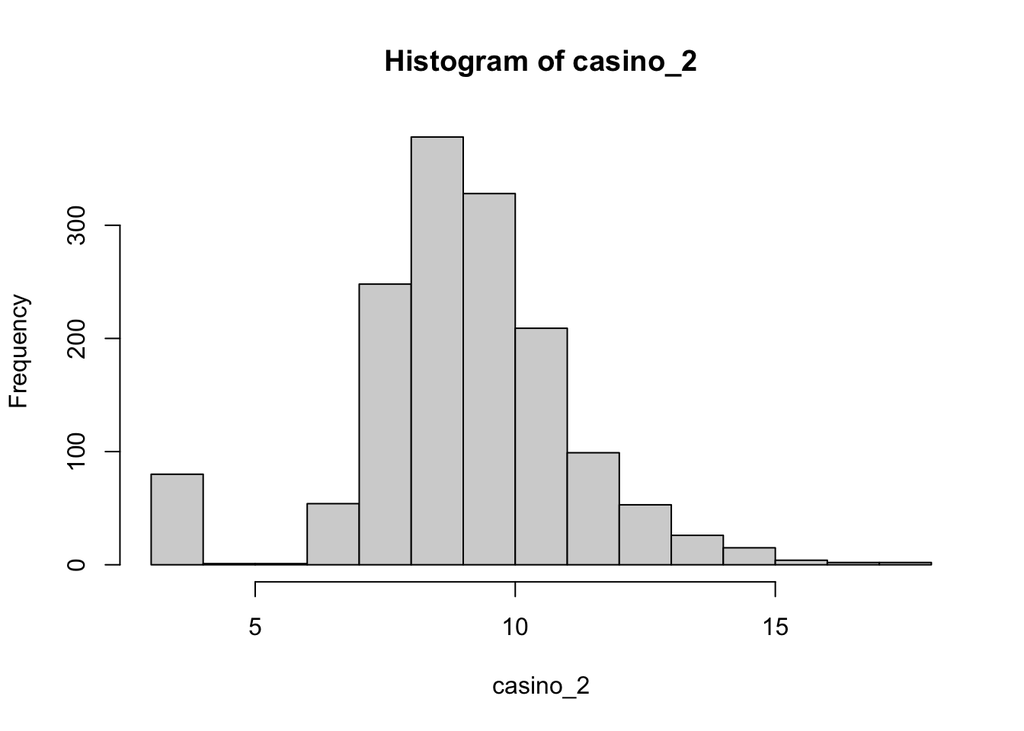

```r
hist(casino_2) # Creates a histogram of the data acquired
```

*The primary difference between the summary and histogram of the casino with 600 spins/day versus the casino with 1,200 spins a day is the mean. The median remains constant between the two, but the casino with 1,200 spins/day has a larger mean. The histograms look very similar, so it is important to look at the quantitative summary. Contextually, with an increase of spins per day there was also an increase in the length of the average streak per day.*